# NYPD_shooting_project

Hanjun Lai

2023-05-15

## Summary

This is a project for course ‘Data Science as a Field’, a data report base on ’ NYPD_Shooting_Incident_Data_*Historic*’ data. For more detail: https://catalog.data.gov/dataset/nypd-shooting-incident-data-historic In the report, we will break it down in some data cleaning, data visualization and data analysis, and we will get insight from the victim patterns.

**we will use following packages:**

```r
  library(readr)
  library(tidyverse)
  library(lubridate)
  library(magrittr)
```

```r
  library(dplyr)
  library(ggplot2)
```

## Step 1: Import the data

```r
library(readr)
data_url <- "https://data.cityofnewyork.us/api/views/833y-fsy8/rows.csv?accessType=DOWNLOAD"
nypd_project_data <- read_csv(data_url)
```

## Step 2: Data Summary and Cleanup

**we will clean up the data for the coming analysis, and then we will use different transformations to create some new data set to run through the analysis that will help we make the conclusion**

```r
# Drop columns
nypd_project_data <- nypd_project_data %>%
                      select(-c(Lon_Lat,Longitude,Latitude,X_COORD_CD, Y_COORD_CD))

# Identify missing values
missing_vals <- is.na(nypd_project_data)
summary(missing_vals)
```

```
##  INCIDENT_KEY    OCCUR_DATE      OCCUR_TIME         BORO
##  Mode :logical   Mode :logical   Mode :logical   Mode :logical
##  FALSE:27312     FALSE:27312     FALSE:27312     FALSE:27312
##
##  LOC_OF_OCCUR_DESC  PRECINCT       JURISDICTION_CODE LOC_CLASSFCTN_DESC
##  Mode :logical     Mode :logical   Mode :logical     Mode :logical
##  FALSE:1716        FALSE:27312     FALSE:27310       FALSE:1716
##  TRUE :25596                       TRUE :2           TRUE :25596
##  LOCATION_DESC   STATISTICAL_MURDER_FLAG PERP_AGE_GROUP   PERP_SEX
##  Mode :logical   Mode :logical           Mode :logical   Mode :logical
##  FALSE:12335     FALSE:27312             FALSE:17968     FALSE:18002
##  TRUE :14977                             TRUE :9344      TRUE :9310
##  PERP_RACE       VIC_AGE_GROUP    VIC_SEX         VIC_RACE
##  Mode :logical   Mode :logical   Mode :logical   Mode :logical
##  FALSE:18002     FALSE:27312     FALSE:27312     FALSE:27312
##  TRUE :9310
```

```r
# Drop the columns that is more that 50% of the data is missing
nypd_project_data <- nypd_project_data %>%
                      select(-c(LOCATION_DESC, LOC_CLASSFCTN_DESC, LOC_OF_OCCUR_DESC))

# Transforming the date type to format =  '%m/%d/%Y'
nypd_project_data$OCCUR_DATE <- as.Date(nypd_project_data$OCCUR_DATE, format =  '%m/%d/%Y')

# Transforming the some columns to factor type
nypd_project_data$PERP_SEX <- as.factor(nypd_project_data$PERP_SEX)
nypd_project_data$VIC_SEX <- as.factor(nypd_project_data$VIC_SEX)
nypd_project_data$BORO <- as.factor(nypd_project_data$BORO)
nypd_project_data$PERP_RACE <- as.factor(nypd_project_data$PERP_RACE)
nypd_project_data$VIC_RACE <- as.factor(nypd_project_data$VIC_RACE)
nypd_project_data$PERP_AGE_GROUP <- as.factor(nypd_project_data$PERP_AGE_GROUP)
nypd_project_data$VIC_AGE_GROUP <- as.factor(nypd_project_data$VIC_AGE_GROUP)

# Summary of the data
summary(nypd_project_data)
```

```
##   INCIDENT_KEY         OCCUR_DATE          OCCUR_TIME
##  Min.   :  9953245   Min.   :2006-01-01   Length:27312
##  1st Qu.: 63860880   1st Qu.:2009-07-18   Class1:hms
##  Median : 90372218   Median :2013-04-29   Class2:difftime
##  Mean   :120860536   Mean   :2014-01-06   Mode  :numeric
##  3rd Qu.:188810230   3rd Qu.:2018-10-15
##  Max.   :261190187   Max.   :2022-12-31
##
##             BORO          PRECINCT      JURISDICTION_CODE
##  BRONX        : 7937   Min.   :  1.00   Min.   :0.0000
##  BROOKLYN     :10933   1st Qu.: 44.00   1st Qu.:0.0000
##  MANHATTAN    : 3572   Median : 68.00   Median :0.0000
##  QUEENS       : 4094   Mean   : 65.64   Mean   :0.3269
##  STATEN ISLAND:  776   3rd Qu.: 81.00   3rd Qu.:0.0000
##                        Max.   :123.00   Max.   :2.0000
##                                         NA's   :2
##  STATISTICAL_MURDER_FLAG PERP_AGE_GROUP   PERP_SEX              PERP_RACE
##  Mode :logical           18-24  :6222   (null):  640   BLACK         :11432
##  FALSE:22046             25-44  :5687   F     :  424   WHITE HISPANIC: 2341
##  TRUE :5266              UNKNOWN:3148   M     :15439   UNKNOWN       : 1836
##                          <18    :1591   U     : 1499   BLACK HISPANIC: 1314
##                          (null) : 640   NA's  : 9310   (null)        :  640
##                          (Other): 680                  (Other)       :  439
##                          NA's   :9344                  NA's          : 9310
##  VIC_AGE_GROUP   VIC_SEX                             VIC_RACE
##  <18    : 2839   F: 2615   AMERICAN INDIAN/ALASKAN NATIVE:   10
##  1022   :    1   M:24686   ASIAN / PACIFIC ISLANDER      :  404
##  18-24  :10086   U:   11   BLACK                         :19439
##  25-44  :12281             BLACK HISPANIC                : 2646
##  45-64  : 1863             UNKNOWN                       :   66
##  65+    :  181             WHITE                         :  698
##  UNKNOWN:   61             WHITE HISPANIC                : 4049
```

## Step 3: Data Visualizations and Analysis

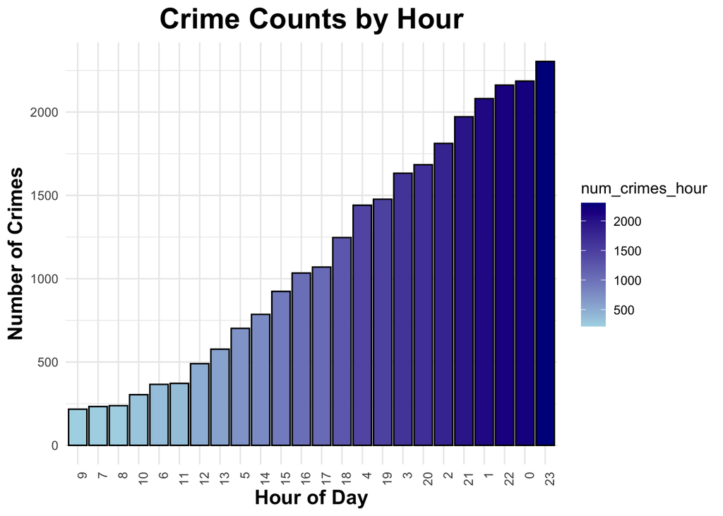

```r
   # Create a dataset of the crime counts by hour
   crime_count_hour <- nypd_project_data %>%
            mutate(hour = lubridate::hour(OCCUR_TIME)) %>%
            group_by(hour) %>%
            summarise(num_crimes_hour = n())

   # Create an enhanced bar plot of the crime counts by hour
   ggplot(crime_count_hour, aes(x = reorder(hour, num_crimes_hour), y = num_crimes_hour, fill = num_crimes_hour)) +
      geom_bar(stat = "identity", color = "black") +
      labs(x = "Hour of Day", y = "Number of Crimes", title = "Crime Counts by Hour") +
      theme_minimal() +
      theme(plot.title = element_text(hjust = 0.5, size = 20, face = "bold"),
            axis.title = element_text(size = 14, face = "bold"),
            axis.text.x = element_text(angle = 90, hjust = 1)) +
      scale_fill_gradient(low = "lightblue", high = "darkblue")
```

**We can tell that from 8:00pm—3:00am(+1day), crime number are all above 1500, indicate a crime peak**

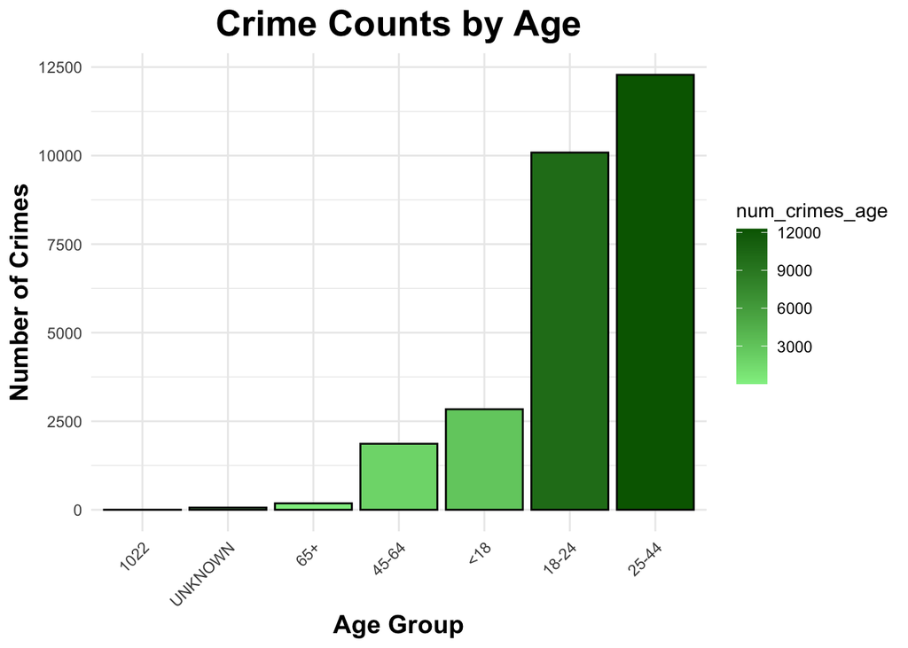

```r
# Create a dataset of the crime counts by age
crime_count_age <- nypd_project_data %>%
          group_by(VIC_AGE_GROUP) %>%
          summarise(num_crimes_age = n())

# Create an enhanced bar plot of the crime counts by age
ggplot(crime_count_age, aes(x = reorder(VIC_AGE_GROUP, num_crimes_age),
                            y = num_crimes_age, fill = num_crimes_age)) +
    geom_bar(stat = "identity", color = "black") +
    labs(x = "Age Group", y = "Number of Crimes", title = "Crime Counts by Age") +
    theme_minimal() +
    theme(plot.title = element_text(hjust = 0.5, size = 20, face = "bold"),
          axis.title = element_text(size = 14, face = "bold"),
          axis.text.x = element_text(angle = 45, hjust = 1)) +
    scale_fill_gradient(low = "lightgreen", high = "darkgreen")
```

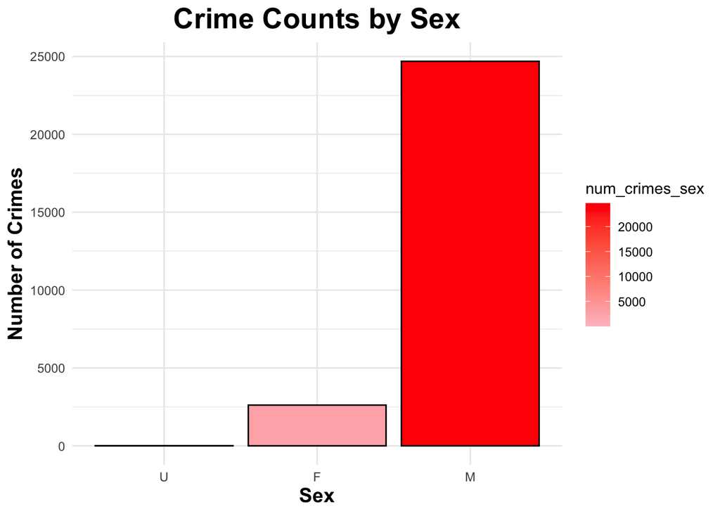

```r
# Create a dataset of the crime counts by sex
crime_count_sex <- nypd_project_data %>%
          group_by(VIC_SEX) %>%
          summarise(num_crimes_sex = n())

      # Create an enhanced bar plot of the crime counts by sex
ggplot(crime_count_sex, aes(x = reorder(VIC_SEX, num_crimes_sex),
                            y = num_crimes_sex, fill = num_crimes_sex)) +
    geom_bar(stat = "identity", color = "black") +
    labs(x = "Sex", y = "Number of Crimes", title = "Crime Counts by Sex") +
    theme_minimal() +
    theme(plot.title = element_text(hjust = 0.5, size = 20, face = "bold"),
          axis.title = element_text(size = 14, face = "bold")) +
    scale_fill_gradient(low = "pink", high = "red")
```

**Male victims are much more than female victims.**

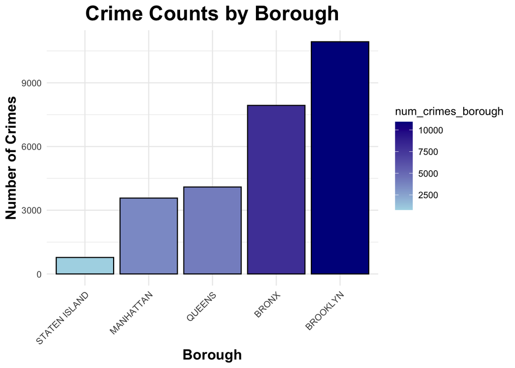

```r
# Create a dataset of the crime counts by Borough
crime_count_borough <- nypd_project_data %>%
          group_by(BORO) %>%
          summarise(num_crimes_borough = n())

     # Create an enhanced bar plot of the crime counts by borough
ggplot(crime_count_borough, aes(x = reorder(BORO, num_crimes_borough),
                            y = num_crimes_borough, fill = num_crimes_borough)) +
    geom_bar(stat = "identity", color = "black") +
    labs(x = "Borough", y = "Number of Crimes", title = "Crime Counts by Borough") +
    theme_minimal() +
    theme(plot.title = element_text(hjust = 0.5, size = 20, face = "bold"),
          axis.title = element_text(size = 14, face = "bold"),
          axis.text.x = element_text(angle = 45, hjust = 1)) +
    scale_fill_gradient(low = "lightblue", high = "darkblue")
```

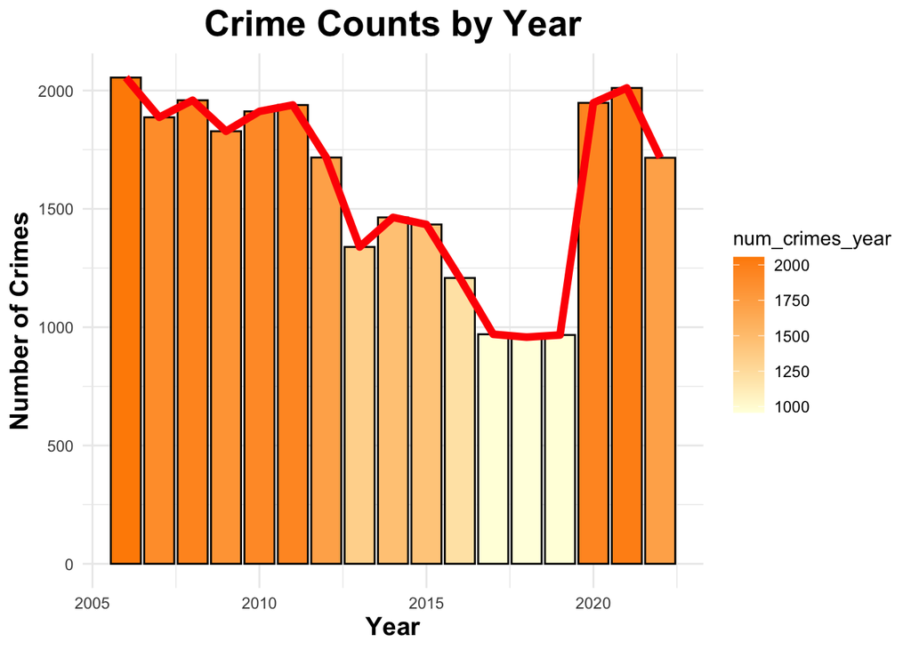

```r
 # Create dataset of the crime counts by year
crime_count_year <- nypd_project_data %>%
                                   mutate(year = lubridate::year(OCCUR_DATE)) %>%
                                   group_by(year) %>%
                                   summarise(num_crimes_year = n())

# Create an enhanced bar plot of the crime counts by year
ggplot(crime_count_year, aes(x = year,
                             y = num_crimes_year, fill = num_crimes_year)) +
    geom_bar(stat = "identity", color = "black") +
    geom_line(data = crime_count_year, color='red',size=2) +
    labs(x = "Year", y = "Number of Crimes", title = "Crime Counts by Year") +
    theme_minimal() +
    theme(plot.title = element_text(hjust = 0.5, size = 20, face = "bold"),
          axis.title = element_text(size = 14, face = "bold")) +
    scale_fill_gradient(low = "lightyellow", high = "darkorange")
```

```r
#install.packages("randomForest") is needed if you never installed this before
library(randomForest)
nypd_project_data$BORO <- as.factor(nypd_project_data$BORO)
nypd_project_data$VIC_SEX <- as.factor(nypd_project_data$VIC_SEX)
nypd_project_data$VIC_RACE <- as.factor(nypd_project_data$VIC_RACE)


model <- randomForest(VIC_AGE_GROUP ~ BORO + VIC_SEX + VIC_RACE + OCCUR_TIME, data = nypd_project_data)


print(model)
```

```
##
## Call:
##  randomForest(formula = VIC_AGE_GROUP ~ BORO + VIC_SEX + VIC_RACE +      OCCUR_TIME, data = nypd_project_data)
##                Type of random forest: classification
##                      Number of trees: 500
## No. of variables tried at each split: 2
##
##         OOB estimate of  error rate: 53.56%
## Confusion matrix:
##         <18 1022 18-24 25-44 45-64 65+ UNKNOWN class.error
## <18      21    0   876  1934     7   0       1   0.9926030
## 1022      0    0     1     0     0   0       0   1.0000000
## 18-24    13    0  2842  7219    11   0       1   0.7182233
## 25-44    10    0  2491  9748    29   1       2   0.2062536
## 45-64     2    0   389  1406    65   0       1   0.9651100
## 65+       0    0    30   139    10   2       0   0.9889503
## UNKNOWN   0    0    17    36     1   0       7   0.8852459
```

```r
predictions <- predict(model, nypd_project_data)

rmse <- sqrt(mean((nypd_project_data$Age - predictions)^2))
print(rmse)
```

```
## [1] NA
```

## Step 4: Conclusion and Bias Identification

However, our analysis should be interpreted with caution due to potential biases and limitations in the data. Firstly, the data is entirely dependent on reported incidents, and thus it could be subject to underreporting bias. Not all shooting incidents are reported or correctly recorded, and the chances of an incident being reported might vary by factors such as location, the socioeconomic status of the victim, and the time of the incident.

As for personal biases, as a data analyst, I aimed to approach this analysis objectively and avoid allowing personal beliefs or preconceptions to influence the interpretation of the results. I made efforts to present the data as it is, and base conclusions strictly on what the data reveals. It is, however, important to be mindful of potential unconscious biases that could affect the analytical process and to continually question the findings and assumptions.

Moving forward, it would be useful to incorporate additional data, such as socioeconomic indicators or more specific location data, to gain a more comprehensive understanding of the factors contributing to these incidents. Moreover, exploring more sophisticated statistical modeling approaches could help in identifying complex relationships and patterns in the data.

Overall, despite the limitations and potential biases, this analysis provides valuable insights into shooting incidents in New York City and offers a basis for further investigations and decision-making.